# ProgettoTerroristiCatanzaro2

2025-11-30

# Introduzione

L’Università di Barcellona, ha creato una rete con i collegamenti fra gli individui coinvolti negli attentati ai treni pendolari a Madrid 11 marzo 2004. (fonti El Pais e El Mundo, giornali spagnoli)

I nodi sono i possibili attentatori o persone che hanno aiutato nella preparazione del attentato (**individui coinvolti**),  
il legame può essere di diverso tipo :  
- fiducia amicizia  
- legami con Al Quaeda e Osama Bin Laden  
- Co-partecipazione in campi di addestramento/guerre  
- Co-partecipazione in altri attacchi terroristici  
**Grafo indiretto**, i legami valgono in entrambe le direzioni

Il **peso dell arco** corrisponde alla forza del legame da 1 a 4.

```
## # A tibble: 6 × 1
##   name
##   <chr>
## 1 Jamal Zougam
## 2 Mohamed Bekkali
## 3 Mohamed Chaoui
## 4 Vinay Kholy
## 5 Suresh Kumar
## 6 Mohamed Chedadi
```

```
## # A tibble: 6 × 3
##    from    to weight
##   <int> <int>  <dbl>
## 1     1     2      1
## 2     1     3      3
## 3     1     4      1
## 4     1     5      1
## 5     1     6      1
## 6     1     7      4
```

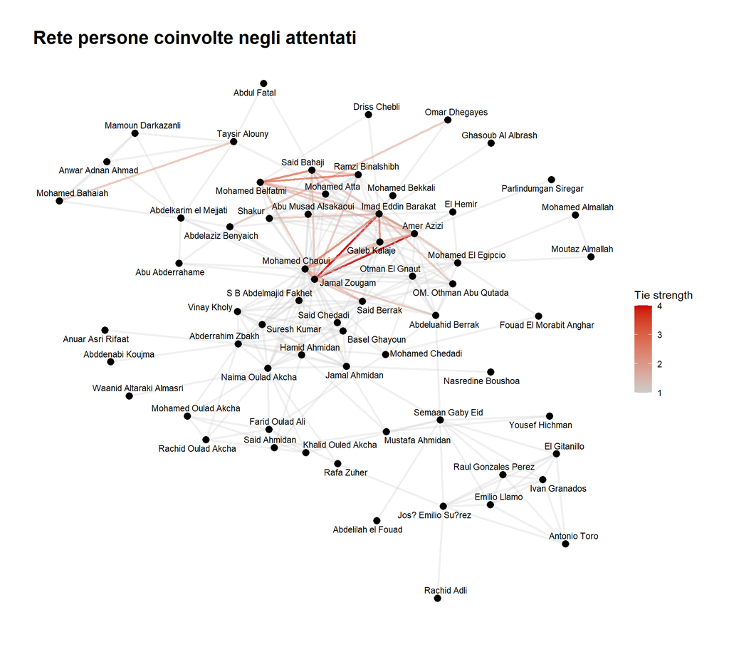

Abbiamo una serie di **Legami molto forti** tra diverse coppie di terroristi centrali nella rete,  
mentre meno forti per più marginali nel grafo.

## 1. Usare le k-componenti per gruppi coesi di terroristi.

### Componenti connesse e k-componenti

Una **componente connessa** di un grafo è un **insieme di nodi** tale che  
per **ogni coppia di nodi** dell’insieme esiste almeno **un cammino indiretto** (senza guardare la direzione del arco) che li collega all’interno del grafo.

Un grafo si dice **connesso** se possiede **una sola componente connessa gigante**, cioè se non esistono nodi o gruppi di nodi isolati rispetto al resto della rete.

Un **cammino** da un nodo $a$ a un nodo $b$ è una **sequenza di archi consecutivi**
$$(a, v_1),\ (v_1, v_2),\ \dots,\ (v_{k-1}, b)$$
in cui l’estremo di ogni arco coincide con l’estremo iniziale del successivo.

Due (o più) cammini da $a$ a $b$ sono detti **cammini indipendenti :** se **non condividono alcun nodo durante il percorso**, apparte il nodo iniziale a e il nodo finale b .

Una **k-componente connessa** è un **insieme di nodi** del grafo tale che,  
per **ogni coppia di nodi** dell’insieme, esistono **almeno $k$ cammini indiretti indipendenti** che li collegano.

#### Esempio bicomponente

Tra ogni coppia di nodi esistono **almeno 2 cammini indipendenti**.

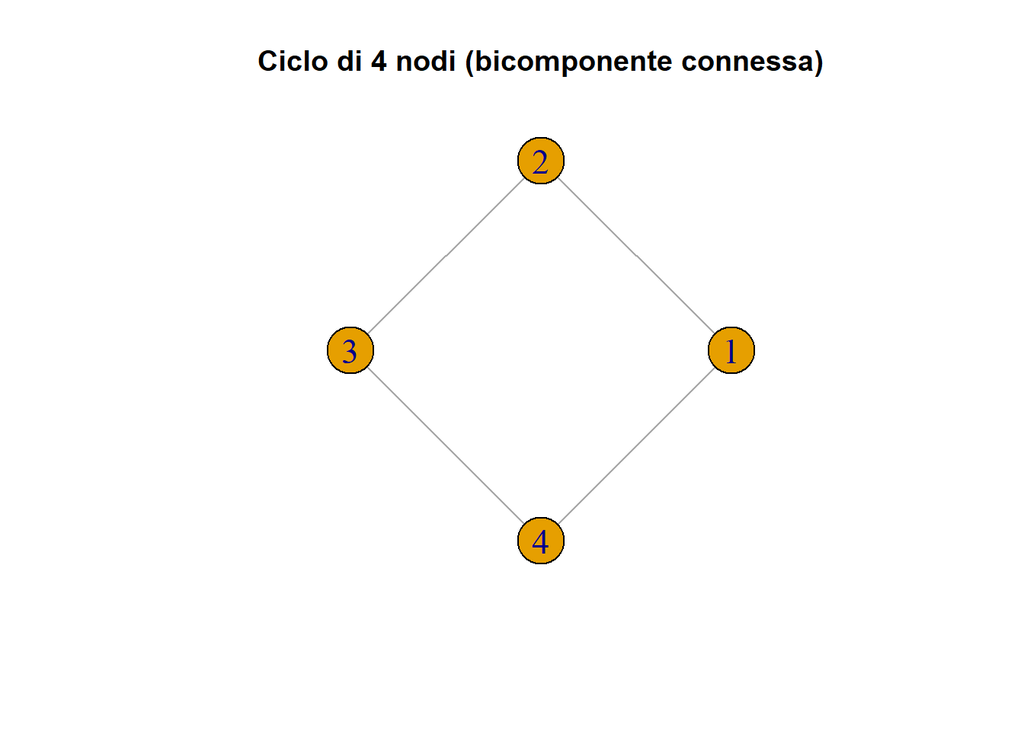

### Ricerchiamo le k-componenti del grafo

#### Estraiamo la Bicomponente più grande nel grafo

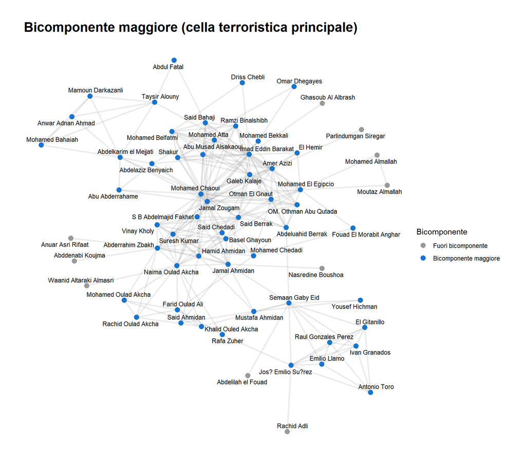

```r
library(tidygraph)
library(ggraph)
library(igraph)

set.seed(123)

# Estraggo i nodi già isolati, tanto so che non faranno della componente connessa
g_main <- g %>%
  activate(nodes) %>%
  mutate(deg = centrality_degree()) %>%    # grado != 0
  filter(deg > 0)


g_igr <- as.igraph(g_main) # uso formule base di igraph

# CALCOLO TUTTE LE BICOMPONENTI PRESENTI NEL GRAFO
bc    <- biconnected_components(g_igr)
bcn   <- bc$components                   # matrice dei nodi x bicomponente (nodi appartente a ogni componente)
bsz   <- lengths(bcn)                    # vettore dimensione bicomponente (grandezza di ogni bicomponente)

# ESTRAGGO DA bsz LA BICOMPONENTE CON DIMENSIONE MAGGIORE (numero maggiore di nodi)
giant_id      <- which.max(bsz)   # trovo l'id
giant_members <- bcn[[giant_id]]  # estraggo il vettore dei i nodi appartenti quella bicomponente


# DIFFERENZIO I NODI DENTRO LA MACRO BICOMPONENTE, DA QUELLI FUORI
group <- rep("Fuori bicomponente", vcount(g_igr))
group[giant_members] <- "Bicomponente maggiore"

g_bc <- g_main %>%
  activate(nodes) %>%
  mutate(                        # aggiungo un attributo a ogni nodo in base se fanno parte del group
    bicomp = factor(group,
                    levels = c("Fuori bicomponente", "Bicomponente maggiore"))
  )

# -----------------------------------------------------

# VISUALIZZO IL GRAFO

# coloro di blu i nodi con attributo "Bicomponente maggiore"


g_bc %>%
  ggraph(layout = "kk") +


  geom_edge_link(
    colour = "grey60",
    alpha  = 0.2,
    width  = 0.9,
    show.legend = FALSE
  ) +

  geom_node_point(aes(color = bicomp), size = 3) +

  geom_node_text(aes(label = name), repel = TRUE, size = 3) +

  scale_color_manual(
    values = c("Fuori bicomponente"    = "grey60",
               "Bicomponente maggiore" = "dodgerblue3"),
    name   = "Bicomponente"
  ) +

  theme_graph() +
  ggtitle("Bicomponente maggiore (cella terroristica principale)")
```

### Interpretazione della bicomponente principale

Osserviamo che i nodi (o i piccoli gruppi di nodi) **periferici** (più esterni al grafo),  
cioè collegati al resto della rete tramite **un solo nodo di entrata**,  
**non possono far parte della bicomponente principale centrale**.

Infatti, per definizione, in una **bicomponente** tra **ogni coppia di nodi** devono esistere **almeno due cammini indipendenti**  
(ossia cammini che non condividono nodi, apparte gli estremi del cammino)

Nel caso di un **nodo periferico** collegato alla rete tramite un unico nodo:  
Qualunque cammino che lo collega agli altri nodi del grafo deve necessariamente passare per **lo stesso nodo di “ingresso”**.  
Non esistono 2 cammini che non passano per quel nodo, quindi **non esistono due cammini indipendenti** che partono/arrivano da quei nodi marginali.

Un esempio evidente è il triangolo esterno  
**Mohamed Almallah – Moutaz Almallah – Mohamed El Egipcio**:

- i due fratelli **Mohamed** e **Moutaz Almallah** **non** fanno parte della bicomponente principale,
- perché tutti i cammini che li collegano al resto della rete passano obbligatoriamente da **Mohamed El Egipcio**,
- ripetendo lo stesso nodo interno, i cammini **non sono indipendenti**.

### Significato pratico delle k-componenti

Le **k-componenti** sono un vero e proprio **indice di robustezza e coesione** del grafo:

- i fratelli **Almallah**, per essere connessi al resto della rete, **dipendono da un unico nodo**, **Mohamed El Egipcio**;
- se questo nodo viene meno (arresto, morte, cambiamento di ruolo, ecc.),  
  i fratelli vengono **immediatamente isolati** dalla componente connessa principale.

In generale:

- tutti i nodi che **non appartengono** alla bicomponente principale risultano **marginali / emarginati** rispetto alla struttura centrale.
- questi nodi sono **più vulnerabili**: è relativamente più facile **“tagliarli fuori”**, rimuovendo uno o pochissimi **nodi chiave**;
- al contrario, i nodi interni alla **bicomponente maggiore** sono legati da più cammini indipendenti, e per isolarli occorrerebbe **rimuovere un maggior numero di nodi**: la loro cellula è quindi **più coesa e più robusta**.

### Osserviamo altre k-componenti principali,

Per arrivare a qual’è la macro k-componente connessa più forte

#### 3-Componente

Verranno esclusi gruppi di nodi con **solo 2 nodi di ingresso**,  
Il gruppo più evidente è quello degli spagnoli, “Toro, Lamo, Granados, Perez …”, che avevano solo 2 contatti principali con la rete, cioè “Gaby edi” e “Ouled Akcha”.

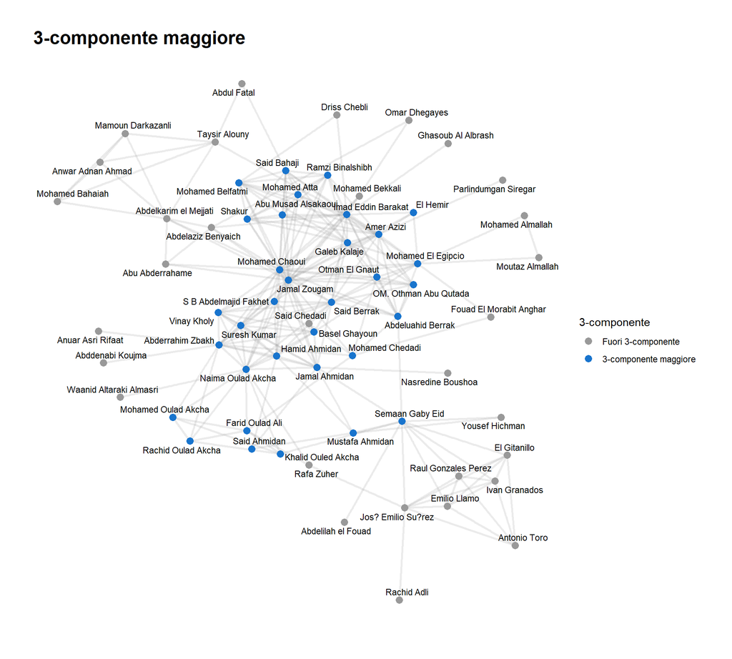

#### 4-Componente

Che rimane comunque simile a quella precedente,  
la componente centrale è **molto densa di archi**, dovrei arrivare **k molto alti** per ridurla ulteriormente.

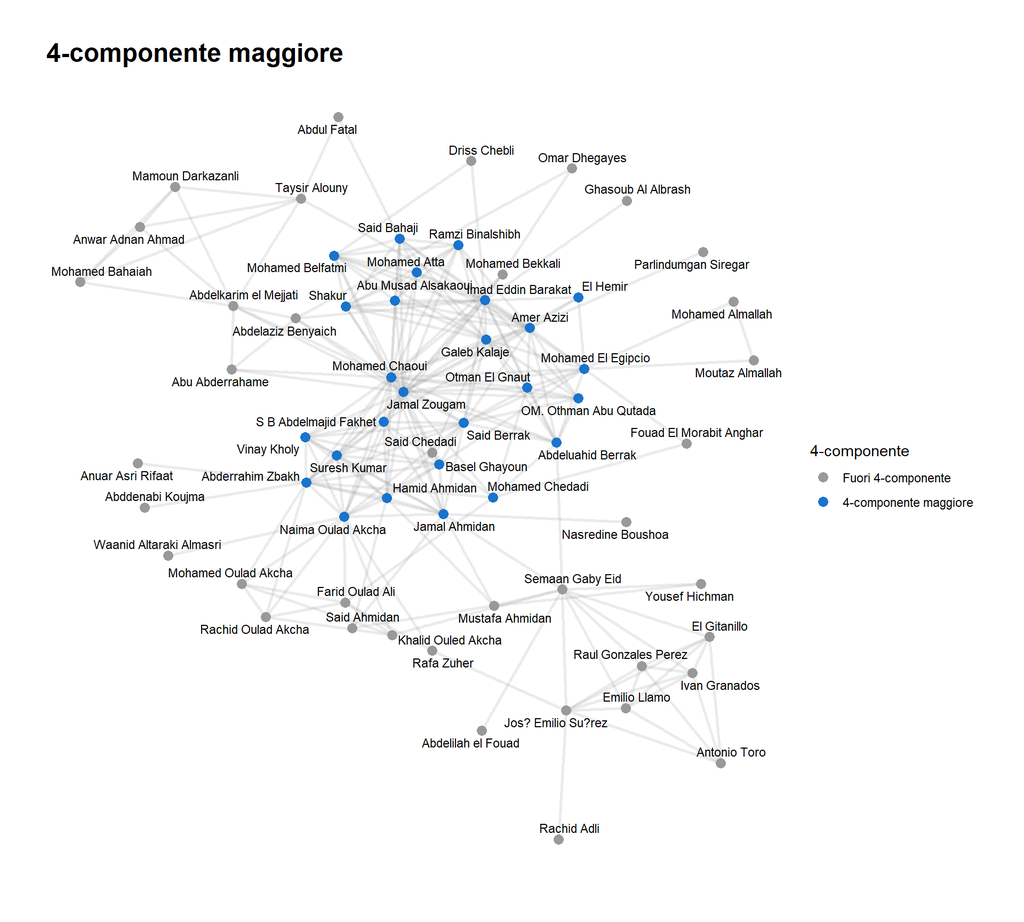

# 2. Strategie di smantellamento della rete

Nel nostro caso la rete rappresenta **una rete di terroristi**.  
Possiamo guardarla da due punti di vista opposti:

- **dal lato della rete di terroristi**, l’obiettivo è **non farsi smantellare**;
- **dal lato della polizia**, l’obiettivo è **smantellare la rete il più rapidamente possibile**, cioè eliminare un nodo deve separare la rete il più possibile (la componente gigante della rete)

I primi nodi che la polizia vorrebbe colpire sono proprio i **nodi di ingresso / ponte**,  
quelli tramite i quali passano la maggior parte delle connessioni dei nodi periferici.

#### Come li riconosciamo?

Per defizione la **Betweenness centrality** di un nodo: più è alta, maggiore è il **numero di cammini** che passano per il nodo.  
Quindi sarà particolarmente alta per i **nodi ponte**, in quanto tutti i percorsi **tra la rete e i nodi marginali** passano da loro.

Se la rete si frammenta più velocemente quando rimuoviamo i nodi in ordine di betweenness (come ci aspettiamo), questo significa che:

- **dal punto di vista della rete**, questi individui sono quelli da proteggere maggiormente;
- **dal punto di vista della polizia**, sono proprio questi i nodi da colpire per primi.

Nel seguito confronteremo lo **smantellamento mirato** (rimozione dei nodi per betweenness decrescente)  
con uno **smantellamento casuale**, in cui i nodi spariscono in modo random (come se la polizia non avvesse una strategia)  
E vediamo quale è quello più veloce.

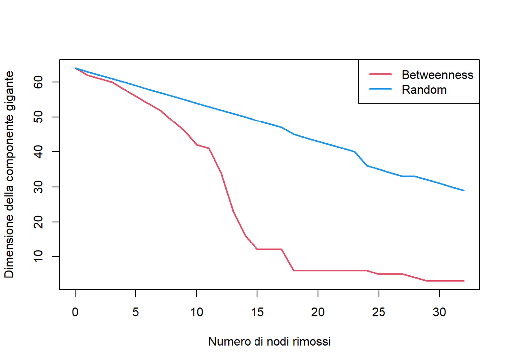

```r
library(tidygraph)
library(igraph)

# ELIMINO I NODI GIA SCONNESSI, l'obbiettivo è sconnettere la rete, non sono utili
g_main <- g %>%
  activate(nodes) %>%
  mutate(deg = centrality_degree()) %>%    # grado != 0
  filter(deg > 0)

g_igr <- as.igraph(g_main)    # uso funzioni di igraph base



# FUNZIONE PERCOLATE (slides)
# dato il grafo, il numero di nodi da rimuovere e l'ordine con cui rimuovere
# inizia a rimuovere un nodo alla volta

# !! RITORNA IL VETTORE CON LE DIMENSIONI DELLA COMPONENTE GIGANTE, PER OGNI NODO RIMOSSO
percolate <- function(g, size, order_vec) {

  giant <- numeric(size + 1)

  c0 <- components(g)
  giant[1] <- max(c0$csize)

  for (i in 1:size) {
    g2 <- delete_vertices(g, order_vec[1:i])
    c2 <- components(g2)
    giant[i + 1] <- max(c2$csize)
  }

  return(giant)
}


# RIMUOVO META' NODI DEL GRAFO,
size <- floor(vcount(g_igr) / 2) # abbastanza per vedere se la rete si sfalda


# VETTORE NODI - ORDINATI RANDOMICAMENTE
set.seed(123)
ord_rand <- sample(vcount(g_igr))


# VETTORE NODI - ORDINATI PER BETWEENESS
bet_vals <- betweenness(g_igr)
ord_bet  <- order(bet_vals, decreasing = TRUE)



# APPLICO LA FUNZIONE percolate PER SUI 2 VETTORI
rand <- percolate(g_igr, size, ord_rand)
bet <- percolate(g_igr, size, ord_bet)

# -------------------------------------------------

# PLOTTO IL GRAFICO (come da slides)

plot(0:size, bet, type = "l", col = 2, lwd = 2,
     xlab = "Numero di nodi rimossi",
     ylab = "Dimensione della componente gigante")

lines(0:size, rand, col = 4, lwd = 2)

legend("topright",
       legend = c("Betweenness", "Random"),
       col = c(2, 4), lty = 1, lwd = 2)
```

Come dedotto, la **componente gigante** si smantella più velocemente eliminando i **nodi ponte** (rosso) piuttosto che eliminandoli random. (blu)

#### Spiegazione

**Random**

Dato che la maggior parte dei nodi è situata nella **componente centrale densamente connessa**,  
molti nodi scelti randomicamente, apparterranno per forza a quel gruppo, (maggiore probabilità)  
la cui eliminazione però non comporta assolutamente **all’esclusione dalla componente gigante di ulteriori nodi**.

Di conseguenza, lo **smantellamento random è praticamente lineare** = (*elimino un nodo → la componente gigante perde un nodo*).

**Betweeness**

Al contrario,

Eliminare i nodi in maniera **sistematica**, seguendo la strategia basata sulla **betweenness**,

porta a uno **smantellamento, quasi esponenziale**, = (*elimino un nodo → la componente gigante perde diversi nodi alla volta*).